# Gaussian mixture model experiments on Leveson

Leslie Huang

4/3/2020

```r
library(reticulate)
library(mclust)
library(ggplot2)
library(tidyr)
library(dplyr)
library(kableExtra)

setwd("/Users/lesliehuang/levesonQs")
set.seed(1234)

np <- reticulate::import("numpy")
```

# Part 0: Correcting more misconceptions

Previously, I thought that questions were assigned to a cluster based on the model fit to the $U$ matrix, and that the *corresponding answers were assigned to the same cluster.* There was some ambiguous wording in the original paper about this that I misinterpreted.

Justine + the source code have confirmed that K-means is applied to $U_{A}$ and $U_{Q}$ separately. They are not necessarily dependent, although the questions are projected into the answer space to form $U_{Q}$. So a question of type 1 could receive an answer of type 2. In my analysis of model output (coming separately), I will examine this.

# Part 1: Choose rank for SVD

We use the SVD reduced from 251 to 250.

Note: snipping only applies to the $U$ matrix (left singular), not to the $\Sigma$ matrix.

## (a) Elbow plot of singular values

```r
# Load data
Sigma_250 <- np$loadtxt("prompt_types_matrix_objs/Sigma_rank_250_nosnip.npy.gz")

Sigma_250 <- data.frame(singular_values=Sigma_250)

summary(Sigma_250)
```

```
##  singular_values
##  Min.   :0.3254
##  1st Qu.:0.9361
##  Median :0.9885
##  Mean   :0.9826
##  3rd Qu.:1.0355
##  Max.   :2.0834
```

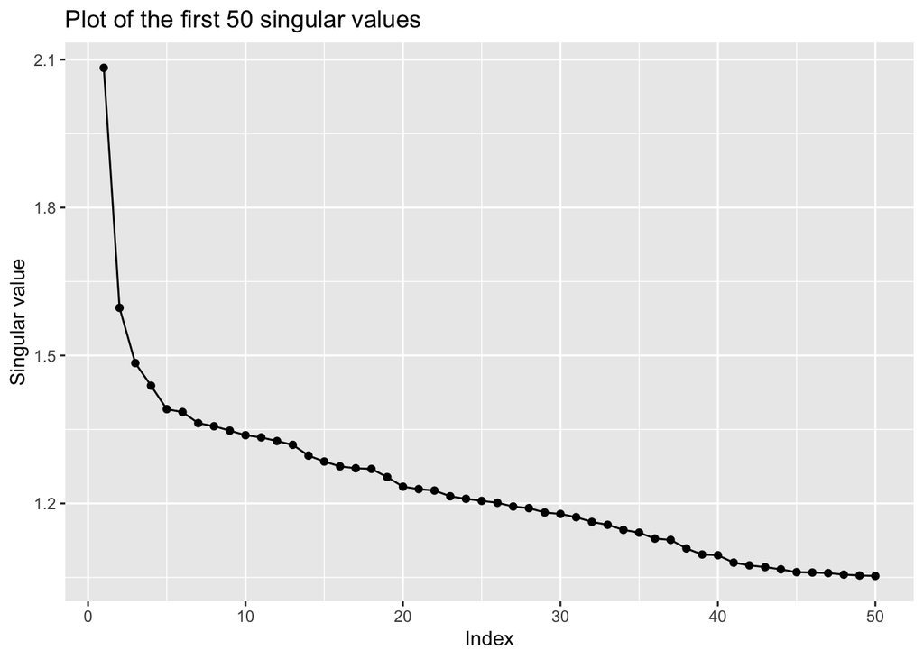

```r
plot_singular_values <- function(df, n) {
  df <- df %>% slice(., 1:n)
  ggp <- ggplot(df,
         aes(x=as.integer(rownames(df)),
             y=singular_values)
         ) +
      geom_point() + ggtitle(paste0("Plot of the first ", n, " singular values")) +
    xlab("Index") + ylab("Singular value") +
    geom_line()

  print(ggp)
}


plot_singular_values(Sigma_250, n=50)
```

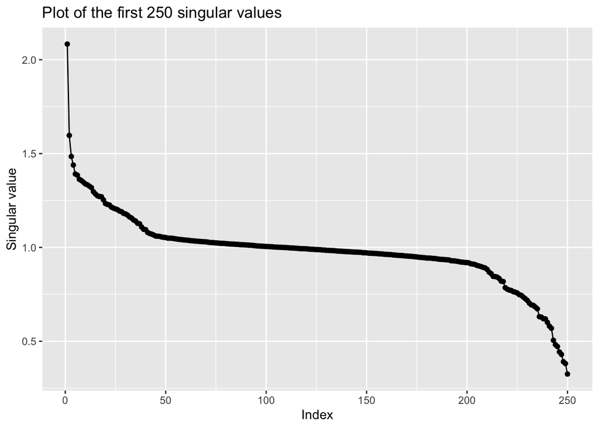

```r
plot_singular_values(Sigma_250, n=nrow(Sigma_250))
```

### Interpretation: Choose $rank=50$ because the large plateau in the plot is around singular value 50.

## (b) Explained variance plot

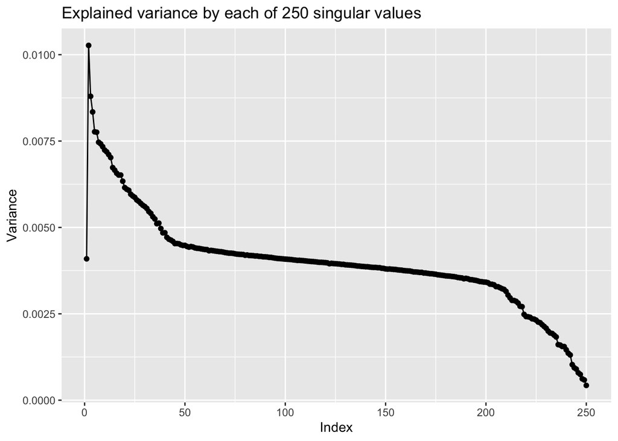

```r
explained_var_250 <- np$loadtxt("prompt_types_matrix_objs/ExplainedVariance__rank_250_nosnip.npy.gz")

explained_var_250 <- data.frame(explained_variance=explained_var_250)

plot_explained_variance <- function(df) {
  ggp <- ggplot(df,
         aes(x=as.integer(rownames(df)),
             y=explained_variance)
         ) +
      geom_point() + ggtitle(paste0("Explained variance by each of ", length(df$explained_variance), " singular values")) +
    xlab("Index") + ylab("Variance") +
    geom_line()

  print(ggp)
}

plot_explained_variance(explained_var_250)
```

### Note: It is strange that the first singular value does not explain the most variance. Maybe this is an argument for snipping the first dimension?

Justine said that snipping the first dimension is done because empirically the first dimension tends to correspond with high frequency features.

## (c) Cumulative explained variance plot

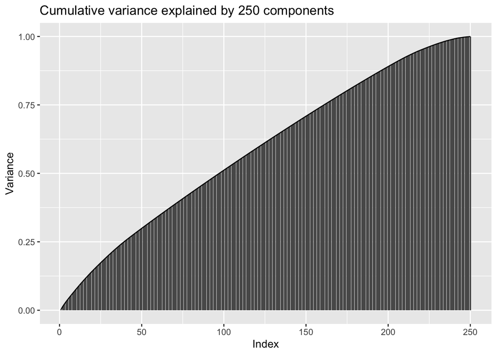

```r
plot_cumulative_variance_explained <- function(df) {
  df$cumulative_variance <- cumsum(df$explained_variance)
  ggp <- ggplot(df,
         aes(x=as.integer(rownames(df)),
             y=cumulative_variance)
         ) +
      geom_bar(stat = "identity") +
    ggtitle(paste0("Cumulative variance explained by ", length(df$explained_variance), " components")) +
    xlab("Index") + ylab("Variance") +
    geom_line()

  print(ggp)
}

plot_cumulative_variance_explained(explained_var_250)
```

### Interpretation: Unclear; maybe 30% of variance explained by first ~50 components, and 50% of variance explained by first ~100 components. We are leaving out a lot of variance by reducing rank. But maybe that variance is noise?

### Upshot: Let’s try reducing rank to 50 and compare that with unreduced SVD.

# Part 2: Choosing k based on BIC for the unreduced matrix

### Legend of GMM types

- E = “univariate, equal variance”,
- V = “univariate, unequal variance”,
- EII = “spherical, equal volume”,
- VII = “spherical, varying volume”,
- EEI = “diagonal, equal volume and shape”,
- VEI = “diagonal, equal shape”,
- EVI = “diagonal, equal volume, varying shape”,
- VVI = “diagonal, varying volume and shape”,
- EEE = “ellipsoidal, equal volume, shape and orientation”,
- EVE = “ellipsoidal, equal volume and orientation”,
- VEE = “ellipsoidal, equal shape and orientation”,
- VVE = “ellipsoidal, equal orientation”,
- EEV = “ellipsoidal, equal volume and shape”,
- VEV = “ellipsoidal, equal shape”

Full list: https://mclust-org.github.io/mclust/reference/mclustModelNames.html

Note: The procedure automatically tries to fit all of the possible models, but I drop the model types that have `BIC=NA` anywhere.

## (a) Choosing k on the unreduced* matrix, no snipping

```
## -------------------------------------------------------
## Density estimation via Gaussian finite mixture modeling
## -------------------------------------------------------
##
## Mclust VEI (diagonal, equal shape) model with 2 components:
##
##  log-likelihood   n  df      BIC      ICL
##        63744.81 172 752 123618.7 123618.7
## [1] ""
## [1] ""
## [1] "Best BIC:  123618.699375932"
```

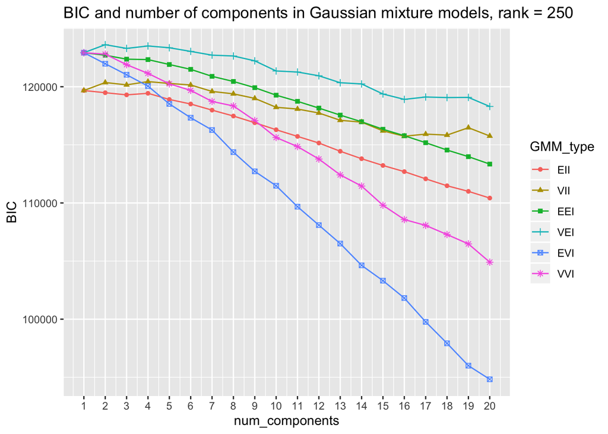

```
## [1] "Full BIC results:"
```

| EII | VII | EEI | VEI | EVI | VVI | num_components |
| --- | --- | --- | --- | --- | --- | --- |
| 119674.3 | 119674.3 | 122928.5 | 122928.5 | 122928.48 | 122928.5 | 1 |
| 119485.9 | 120362.1 | 122713.6 | 123618.7 | 121979.73 | 122801.2 | 2 |
| 119301.3 | 120161.5 | 122372.7 | 123298.4 | 121031.03 | 121899.0 | 3 |
| 119435.7 | 120443.4 | 122336.1 | 123507.8 | 120054.10 | 121149.3 | 4 |
| 118906.4 | 120284.1 | 121913.7 | 123354.8 | 118524.48 | 120250.7 | 5 |
| 118514.8 | 120151.6 | 121496.7 | 123041.1 | 117333.50 | 119687.7 | 6 |
| 117988.3 | 119595.9 | 120895.2 | 122717.4 | 116276.52 | 118735.3 | 7 |
| 117481.0 | 119388.9 | 120453.9 | 122646.2 | 114373.04 | 118346.8 | 8 |
| 116904.6 | 118999.0 | 119921.0 | 122228.2 | 112720.76 | 117090.3 | 9 |
| 116300.8 | 118231.8 | 119274.6 | 121357.1 | 111481.19 | 115632.9 | 10 |
| 115727.9 | 118082.0 | 118744.1 | 121266.0 | 109680.18 | 114851.2 | 11 |
| 115158.7 | 117740.7 | 118164.2 | 120943.6 | 108093.26 | 113780.1 | 12 |
| 114449.5 | 117112.8 | 117558.5 | 120345.3 | 106505.37 | 112415.1 | 13 |
| 113807.1 | 116955.1 | 116987.3 | 120241.5 | 104630.90 | 111454.4 | 14 |
| 113225.7 | 116202.8 | 116340.7 | 119375.2 | 103312.96 | 109802.2 | 15 |
| 112697.0 | 115740.8 | 115786.8 | 118913.4 | 101818.85 | 108574.3 | 16 |
| 112076.3 | 115925.4 | 115185.3 | 119115.6 | 99768.28 | 108069.5 | 17 |
| 111479.7 | 115838.7 | 114553.1 | 119067.7 | 97923.57 | 107283.9 | 18 |
| 110998.7 | 116477.3 | 113985.3 | 119083.3 | 96002.13 | 106477.6 | 19 |
| 110422.4 | 115760.5 | 113345.4 | 118303.1 | 94827.17 | 104906.1 | 20 |

```r
generate_bics_plot <- function(U_prompt_norm, max_components=20) {

  gmm <- densityMclust(U_prompt_norm, G = seq(1,max_components,1))
  rank <- ncol(U_prompt_norm)

  print(summary(gmm))

  print("")
  print("")
  print(paste("Best BIC: ", gmm$bic))

  BIC_df <- as.data.frame(gmm$BIC[,]) %>% select_if(~ !any(is.na(.)))

  model_names <- colnames(BIC_df)
  BIC_df$num_components <- rownames(BIC_df)
  data_long <- gather(BIC_df, GMM_type, BIC, model_names, factor_key=TRUE)
  data_long$num_components <- as.integer(data_long$num_components)

  ggp <- ggplot(data_long, aes(x=num_components, y=BIC, group=GMM_type)) +
  geom_point(aes(shape=GMM_type, color=GMM_type)) +
  geom_line(aes(color=GMM_type)) +
  ggtitle(paste("BIC and number of components in Gaussian mixture models, rank =", rank)) +
  scale_x_continuous(breaks = scales::pretty_breaks(n = min(25, max(data_long$num_components))
                                                    ))

  print(ggp)
  print("Full BIC results:")

  return(
    BIC_df %>%
  kable() %>%
  kable_styling(bootstrap_options = c("striped", "hover", "condensed"),
                full_width=FALSE) %>%
  scroll_box(height = "350px")
  )
}

U_prompt_norm <- np$loadtxt("prompt_types_matrix_objs/U_prompt_norm_rank_250_nosnip.npy.gz")

generate_bics_plot(U_prompt_norm, max_components=20)
```

```
## -------------------------------------------------------
## Density estimation via Gaussian finite mixture modeling
## -------------------------------------------------------
##
## Mclust VEI (diagonal, equal shape) model with 2 components:
##
##  log-likelihood   n  df      BIC      ICL
##        63744.81 172 752 123618.7 123618.7
## [1] ""
## [1] ""
## [1] "Best BIC:  123618.699375932"
```

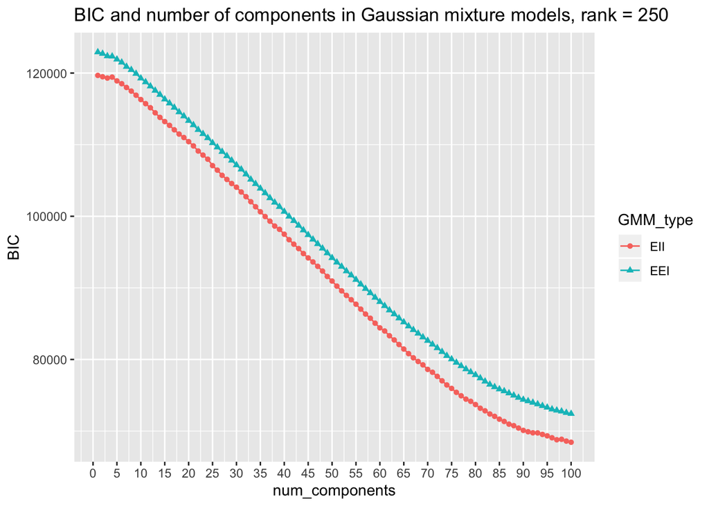

```
## [1] "Full BIC results:"
```

| EII | EEI | num_components |
| --- | --- | --- |
| 119674.32 | 122928.48 | 1 |
| 119485.86 | 122713.64 | 2 |
| 119301.30 | 122372.69 | 3 |
| 119435.72 | 122336.06 | 4 |
| 118906.35 | 121913.71 | 5 |
| 118514.75 | 121496.74 | 6 |
| 117988.33 | 120895.16 | 7 |
| 117481.01 | 120453.95 | 8 |
| 116904.59 | 119920.95 | 9 |
| 116300.78 | 119274.59 | 10 |
| 115727.93 | 118744.14 | 11 |
| 115158.66 | 118164.17 | 12 |
| 114449.49 | 117558.52 | 13 |
| 113807.12 | 116987.34 | 14 |
| 113225.66 | 116340.65 | 15 |
| 112697.00 | 115786.81 | 16 |
| 112076.31 | 115185.26 | 17 |
| 111479.72 | 114553.06 | 18 |
| 110998.71 | 113985.27 | 19 |
| 110422.40 | 113345.44 | 20 |
| 109829.34 | 112746.98 | 21 |
| 109110.73 | 112080.07 | 22 |
| 108541.40 | 111510.21 | 23 |
| 107972.45 | 110936.71 | 24 |
| 107072.27 | 110244.79 | 25 |
| 106444.04 | 109644.07 | 26 |
| 105717.40 | 109019.76 | 27 |
| 105144.70 | 108423.41 | 28 |
| 104573.77 | 107800.25 | 29 |
| 104057.42 | 107151.08 | 30 |

[output cut: 70 more lines]

```r
generate_bics_plot(U_prompt_norm, max_components=100)
```

## (b) Choosing k on the unreduced* matrix, with snipping

## In other words: Does snipping make a difference?

```
## -------------------------------------------------------
## Density estimation via Gaussian finite mixture modeling
## -------------------------------------------------------
##
## Mclust VEI (diagonal, equal shape) model with 2 components:
##
##  log-likelihood   n  df      BIC      ICL
##        61890.88 172 749 119926.3 119926.3
## [1] ""
## [1] ""
## [1] "Best BIC:  119926.292676602"
```

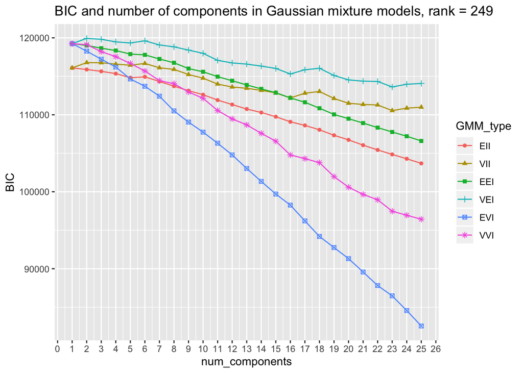

```
## [1] "Full BIC results:"
```

| EII | VII | EEI | VEI | EVI | VVI | num_components |
| --- | --- | --- | --- | --- | --- | --- |
| 116089.6 | 116089.6 | 119243.4 | 119243.4 | 119243.38 | 119243.38 | 1 |
| 115888.9 | 116781.1 | 119015.5 | 119926.3 | 118270.28 | 119112.40 | 2 |
| 115647.7 | 116763.2 | 118651.1 | 119810.1 | 117222.20 | 118206.74 | 3 |
| 115348.6 | 116582.3 | 118349.5 | 119473.5 | 116200.90 | 117558.39 | 4 |
| 114819.3 | 116443.6 | 117886.2 | 119333.0 | 114655.29 | 116669.99 | 5 |
| 114932.3 | 116673.4 | 117788.3 | 119610.6 | 113706.44 | 115691.23 | 6 |
| 114334.8 | 116109.1 | 117252.0 | 119073.2 | 112419.31 | 114439.78 | 7 |
| 113718.0 | 115900.2 | 116757.9 | 118830.0 | 110506.05 | 114039.15 | 8 |
| 113132.9 | 115235.7 | 116006.5 | 118406.1 | 109051.16 | 112965.01 | 9 |
| 112612.1 | 114761.1 | 115589.0 | 117985.6 | 107747.09 | 112141.42 | 10 |
| 111910.4 | 113990.4 | 114958.0 | 117073.3 | 106308.47 | 110555.62 | 11 |
| 111330.5 | 113610.3 | 114424.6 | 116737.9 | 104786.10 | 109470.87 | 12 |
| 110750.1 | 113447.5 | 113879.2 | 116586.8 | 103024.85 | 108688.08 | 13 |
| 110297.7 | 113174.6 | 113365.4 | 116328.2 | 101345.78 | 107594.94 | 14 |
| 109750.8 | 112849.0 | 112868.7 | 116024.4 | 99700.53 | 106565.19 | 15 |
| 109089.7 | 112188.1 | 112193.7 | 115304.9 | 98264.32 | 104784.25 | 16 |
| 108622.6 | 112808.0 | 111628.6 | 115850.4 | 96212.33 | 104304.80 | 17 |
| 108052.4 | 113029.5 | 110854.1 | 116044.5 | 94192.90 | 103781.47 | 18 |
| 107337.1 | 112118.3 | 110048.7 | 115109.0 | 92752.69 | 101968.76 | 19 |
| 106743.9 | 111499.3 | 109494.2 | 114533.1 | 91309.86 | 100591.10 | 20 |
| 106053.8 | 111343.5 | 108925.4 | 114371.4 | 89574.81 | 99656.69 | 21 |
| 105436.6 | 111276.3 | 108334.5 | 114327.5 | 87814.36 | 98958.69 | 22 |
| 104851.3 | 110546.9 | 107767.4 | 113618.2 | 86474.37 | 97471.75 | 23 |
| 104286.3 | 110864.7 | 107216.5 | 113969.5 | 84565.77 | 96946.19 | 24 |
| 103685.5 | 110990.4 | 106600.5 | 114073.8 | 82558.86 | 96430.40 | 25 |

```r
U_prompt_norm <- np$loadtxt("prompt_types_matrix_objs/U_prompt_norm_rank_250_snip.npy.gz")

generate_bics_plot(U_prompt_norm, max_components=25)
```

### Interpretation: What k would I choose based on BIC? Unclear.

But snipping the first dimension doesn’t seem to make a difference, so I guess we can do it.

# Part 3: Choosing k based on BIC for the reduced matrix

## (a) Reduced, not snipped (rank = 50)

```
## -------------------------------------------------------
## Density estimation via Gaussian finite mixture modeling
## -------------------------------------------------------
##
## Mclust VEI (diagonal, equal shape) model with 13 components:
##
##  log-likelihood   n  df     BIC     ICL
##        9334.244 172 724 14941.7 14941.6
## [1] ""
## [1] ""
## [1] "Best BIC:  14941.7013258253"
```

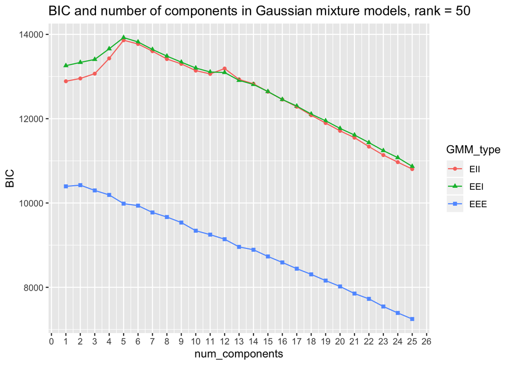

```
## [1] "Full BIC results:"
```

| EII | EEI | EEE | num_components |
| --- | --- | --- | --- |
| 12888.66 | 13258.25 | 10395.159 | 1 |
| 12954.90 | 13335.56 | 10424.038 | 2 |
| 13068.34 | 13406.27 | 10298.201 | 3 |
| 13431.11 | 13658.43 | 10191.906 | 4 |
| 13861.00 | 13924.61 | 9985.202 | 5 |
| 13772.72 | 13820.74 | 9937.458 | 6 |
| 13602.19 | 13642.27 | 9775.789 | 7 |
| 13415.34 | 13484.83 | 9667.562 | 8 |
| 13300.45 | 13341.57 | 9536.219 | 9 |
| 13140.74 | 13202.84 | 9342.558 | 10 |
| 13062.61 | 13107.73 | 9249.725 | 11 |
| 13189.97 | 13096.10 | 9141.548 | 12 |
| 12932.49 | 12909.52 | 8958.363 | 13 |
| 12828.79 | 12812.59 | 8891.009 | 14 |
| 12640.26 | 12644.37 | 8732.115 | 15 |
| 12455.10 | 12456.26 | 8590.107 | 16 |
| 12283.84 | 12299.22 | 8442.001 | 17 |
| 12082.77 | 12110.22 | 8307.283 | 18 |
| 11897.11 | 11950.62 | 8159.572 | 19 |
| 11712.26 | 11769.83 | 8020.338 | 20 |
| 11550.05 | 11612.61 | 7851.855 | 21 |
| 11338.09 | 11433.10 | 7726.155 | 22 |
| 11136.76 | 11242.81 | 7544.744 | 23 |
| 10969.29 | 11076.27 | 7392.004 | 24 |
| 10804.49 | 10869.15 | 7248.096 | 25 |

```r
# Load data
U_prompt_norm <- np$loadtxt("prompt_types_matrix_objs/U_prompt_norm_rank_50_nosnip.npy.gz")

generate_bics_plot(U_prompt_norm, 25)
```

## (b) Reduced, snipped (rank = 49)

```
## -------------------------------------------------------
## Density estimation via Gaussian finite mixture modeling
## -------------------------------------------------------
##
## Mclust VEI (diagonal, equal shape) model with 13 components:
##
##  log-likelihood   n  df      BIC      ICL
##        7880.744 172 710 12106.77 12106.72
## [1] ""
## [1] ""
## [1] "Best BIC:  12106.7662547261"
```

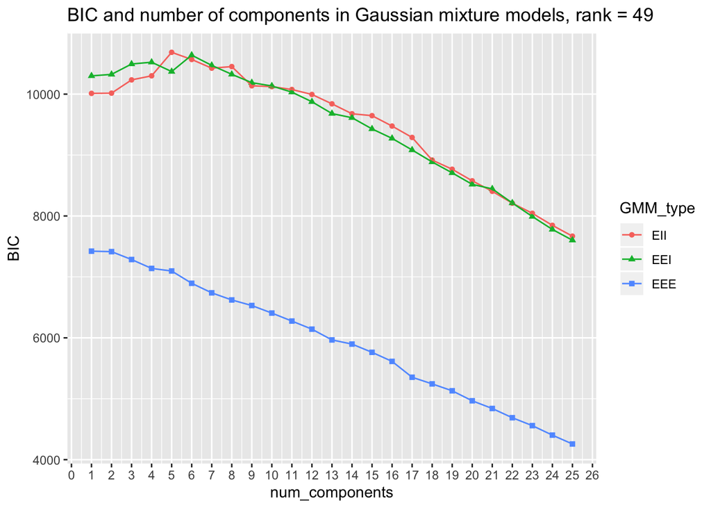

```
## [1] "Full BIC results:"
```

| EII | EEI | EEE | num_components |
| --- | --- | --- | --- |
| 10012.435 | 10299.756 | 7422.420 | 1 |
| 10016.127 | 10324.321 | 7414.864 | 2 |
| 10233.887 | 10494.528 | 7285.287 | 3 |
| 10300.525 | 10524.168 | 7139.226 | 4 |
| 10686.631 | 10370.368 | 7097.217 | 5 |
| 10568.919 | 10639.877 | 6895.247 | 6 |
| 10426.341 | 10472.038 | 6738.557 | 7 |
| 10452.393 | 10325.355 | 6621.892 | 8 |
| 10137.060 | 10188.397 | 6530.203 | 9 |
| 10123.390 | 10134.040 | 6406.366 | 10 |
| 10076.136 | 10032.619 | 6275.270 | 11 |
| 9994.795 | 9875.031 | 6142.221 | 12 |
| 9840.591 | 9681.325 | 5965.651 | 13 |
| 9678.053 | 9612.895 | 5897.272 | 14 |
| 9646.665 | 9429.152 | 5762.137 | 15 |
| 9475.681 | 9273.872 | 5613.230 | 16 |
| 9289.112 | 9083.405 | 5352.927 | 17 |
| 8917.931 | 8886.901 | 5244.103 | 18 |
| 8766.948 | 8707.647 | 5130.761 | 19 |
| 8577.366 | 8519.255 | 4966.483 | 20 |
| 8405.103 | 8444.829 | 4840.226 | 21 |
| 8209.982 | 8213.623 | 4688.528 | 22 |
| 8044.119 | 7990.693 | 4558.714 | 23 |
| 7846.687 | 7779.170 | 4402.858 | 24 |
| 7668.777 | 7602.423 | 4257.610 | 25 |

```r
# Load data
U_prompt_norm <- np$loadtxt("prompt_types_matrix_objs/U_prompt_norm_rank_50_snip.npy.gz")

generate_bics_plot(U_prompt_norm, 25)
```

# Conclusions

Up next: choosing k with Bayesian Gaussian mixture (back in Python)?